# Outline

### 1. Data Analysis Intro

### 2. Jupyter Notebooks

### 3. Case study

Based on Udacity nanodegree program [Data Analyst](https://www.udacity.com/course/data-analyst-nanodegree--nd002)

# 1. Data Analysis Intro

# Data Analysis

### Why

- Get useful information from data
- Better understand your customers, business, politics, nature, ...
- Make better decisions

### How

- Wrangle data
- Explore data
- Communicate insights

## Data Analysis Application Examples

- Netflix: personalized movie recommendations
- Facebook: news feed ranking
- Walmart: find out what to stock in their stores
- Sports: analyzing and predicting performance
- Pharmaceutical research: find chemicals compounds that are likely to make effective pharmaceutical drugs

## Data Analysis Process

- Questions
  - What do you want to find out?
- Wrangle: gather, assess, and clean data
  - Collect data
  - Assess for problems in data quality or structure
  - Clean by modifying/converting/removing data
- Explore: Perform Exploratory Data Analysis (EDA)
  - Find patterns
  - Visualize relationships
  - Build intuition about the data
- Draw conclusions
  - Statistics
  - Machine Learning (outside of scope here)
- Communicate
  - Share and explain your findings and insights
  - Reports, slides, blog posts, emails, conversations

# 2. Jupyter Notebooks

## What are Jupyter Notebooks

- Web application
- Jupyter notebooks
  - can be viewed and edited in the browser
  - are a form of [literate programming](https://en.wikipedia.org/wiki/Literate_programming) where documentation is written along with the code. [Donald Knuth](https://en.wikipedia.org/wiki/Donald_Knuth):

    > Instead of imagining that our main task is to instruct a computer what to do, let us concentrate rather on explaining to human beings what we want a computer to do.
  - combine text, math expressions, code, and plots in one document
  - [support](https://github.com/jupyter/jupyter/wiki/Jupyter-kernels) multiple programming languages, including Python

## Jupyter Notebook Contents

- Markdown cells
  - text: [Markdown](https://daringfireball.net/projects/markdown/basics)
  - math expressions: LaTeX
- Code cells
  - code: here, we use [Python](https://www.python.org/)
  - visualization: [plots](https://matplotlib.org/)

## Jupyter Notebook [Demo](http://localhost:8888/notebooks/demo.ipynb)

# 3. Case Study

# Case Study: GDP per capita and democracy index of countries

- Question: how does the wealth of a country (measured by its GDP per capita) correlate with its regime type (measured by its democracy index)
- A project I did in the Udacity nanodegree program [Data Analyst](https://www.udacity.com/course/data-analyst-nanodegree--nd002)
- Also published on [GitHub](https://github.com/drdtr/udacity-data-analyst-project-2-introduction-to-data-analysis/tree/main/project), and can be viewed online with [nbviewer](https://nbviewer.jupyter.org/github/drdtr/udacity-data-analyst-project-2-introduction-to-data-analysis/blob/main/project/02_exploratory_data_analysis_and_conclusions.ipynb).
- Data sets:
  - GDP per capita
  - democracy index
  - total population
  - fuel exports
- Available under the [CC BY 4.0](https://creativecommons.org/licenses/by/4.0/) from:
  - [www.gapminder.org](https://www.gapminder.org/)
  - [World Bank Open Data](https://data.worldbank.org/)

## First overview of data: most democratic countries

```python
df1
```

| Country code | Country | Democracy index | Population, in millions | GDP per capita, in thousands | Rank |
| --- | --- | --- | --- | --- | --- |
| nor | Norway | 98.7 | 5.31 | 81.7 | 1 |
| isl | Iceland | 95.8 | 0.35 | 73.0 | 2 |
| swe | Sweden | 93.9 | 10.18 | 54.6 | 3 |
| nzl | New Zealand | 92.6 | 4.84 | 42.9 | 4 |
| dnk | Denmark | 92.2 | 5.79 | 61.6 | 5 |
| irl | Ireland | 91.5 | 4.87 | 78.6 | 6 |
| can | Canada | 91.5 | 37.06 | 46.3 | 7 |
| fin | Finland | 91.4 | 5.52 | 50.0 | 8 |
| aus | Australia | 90.9 | 24.98 | 57.4 | 9 |
| che | Switzerland | 90.3 | 8.51 | 82.8 | 10 |
| nld | Netherlands | 88.9 | 17.23 | 53.0 | 11 |
| lux | Luxembourg | 88.1 | 0.61 | 116.7 | 12 |
| deu | Germany | 86.8 | 82.91 | 47.8 | 13 |
| gbr | United Kingdom | 85.3 | 66.46 | 43.0 | 14 |
| ury | Uruguay | 83.8 | 3.45 | 17.3 | 15 |
| aut | Austria | 82.9 | 8.84 | 51.5 | 16 |
| mus | Mauritius | 82.2 | 1.27 | 11.2 | 17 |
| mlt | Malta | 82.1 | 0.48 | 30.4 | 18 |
| esp | Spain | 80.8 | 46.80 | 30.4 | 19 |
| cri | Costa Rica | 80.7 | 5.00 | 12.1 | 20 |
| kor | South Korea | 80.0 | 51.61 | 33.4 | 21 |
| jpn | Japan | 79.9 | 126.53 | 39.2 | 22 |
| chl | Chile | 79.7 | 18.73 | 15.9 | 23 |
| est | Estonia | 79.7 | 1.32 | 23.2 | 24 |
| usa | United States | 79.6 | 326.69 | 63.0 | 25 |
| cpv | Cape Verde | 78.8 | 0.54 | 3.6 | 26 |
| prt | Portugal | 78.4 | 10.28 | 23.6 | 27 |
| bwa | Botswana | 78.1 | 2.25 | 8.3 | 28 |
| fra | France | 78.0 | 66.97 | 41.6 | 29 |
| isr | Israel | 77.9 | 8.88 | 41.7 | 30 |

## First overview of data: wealthiest countries

```python
df1
```

| Country code | Country | Democracy index | Population, in millions | GDP per capita, in thousands | Rank |
| --- | --- | --- | --- | --- | --- |
| lux | Luxembourg | 88.1 | 0.61 | 116.7 | 1 |
| che | Switzerland | 90.3 | 8.51 | 82.8 | 2 |
| nor | Norway | 98.7 | 5.31 | 81.7 | 3 |
| irl | Ireland | 91.5 | 4.87 | 78.6 | 4 |
| isl | Iceland | 95.8 | 0.35 | 73.0 | 5 |
| sgp | Singapore | 63.8 | 5.64 | 66.2 | 6 |
| qat | Qatar | 31.9 | 2.78 | 65.9 | 7 |
| usa | United States | 79.6 | 326.69 | 63.0 | 8 |
| dnk | Denmark | 92.2 | 5.79 | 61.6 | 9 |
| aus | Australia | 90.9 | 24.98 | 57.4 | 10 |
| swe | Sweden | 93.9 | 10.18 | 54.6 | 11 |
| nld | Netherlands | 88.9 | 17.23 | 53.0 | 12 |
| aut | Austria | 82.9 | 8.84 | 51.5 | 13 |
| fin | Finland | 91.4 | 5.52 | 50.0 | 14 |
| hkg | Hong Kong, China | 61.5 | 7.45 | 48.5 | 15 |
| deu | Germany | 86.8 | 82.91 | 47.8 | 16 |
| bel | Belgium | 77.8 | 11.43 | 47.6 | 17 |
| can | Canada | 91.5 | 37.06 | 46.3 | 18 |
| are | United Arab Emirates | 27.6 | 9.63 | 43.8 | 19 |
| gbr | United Kingdom | 85.3 | 66.46 | 43.0 | 20 |
| nzl | New Zealand | 92.6 | 4.84 | 42.9 | 21 |
| isr | Israel | 77.9 | 8.88 | 41.7 | 22 |
| fra | France | 78.0 | 66.97 | 41.6 | 23 |
| jpn | Japan | 79.9 | 126.53 | 39.2 | 24 |
| ita | Italy | 77.1 | 60.42 | 34.6 | 25 |
| kwt | Kuwait | 38.5 | 4.14 | 34.0 | 26 |
| kor | South Korea | 80.0 | 51.61 | 33.4 | 27 |
| mlt | Malta | 82.1 | 0.48 | 30.4 | 28 |
| esp | Spain | 80.8 | 46.80 | 30.4 | 29 |
| cyp | Cyprus | 75.9 | 1.19 | 28.7 | 30 |

## Distribution of population by regime type

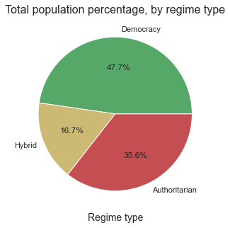

```python
plot_pie_annotated(pop_in_bn_by_regime_type,
                   title="Total population percentage, by regime type",
                   colors=ColorRegimeType.values,
                   autopct='%.1f%%')
```

## The biggest democratic countries

```python
df[df[ColDem.regime_type] == RegimeType.democracy].sort_values(ColPop.population, ascending=False).head()
```

| Country code | Country | Year | GDP per capita (PPP dollars) | GDP per capita | Population | Democracy index | Regime type | Fuel exports (% of merchandise exports) | GDP total | GDP total (PPP dollars) | Above-average GDP per capita (PPP dollars) | Above-average GDP per capita | GDP level |
| --- | --- | --- | --- | --- | --- | --- | --- | --- | --- | --- | --- | --- | --- |
| ind | India | 2018 | 6899 | 2005.863005 | 1.352617e+09 | 72.3 | Democracy | 15.067451 | 2.713165e+12 | 9.331707e+12 | False | False | Below-average |
| usa | United States | 2018 | 55681 | 62996.471285 | 3.266875e+08 | 79.6 | Democracy | 13.529994 | 2.058016e+13 | 1.819029e+13 | True | True | Above-average |
| idn | Indonesia | 2018 | 11606 | 3893.846425 | 2.676634e+08 | 63.9 | Democracy | 23.310028 | 1.042240e+12 | 3.106502e+12 | False | False | Below-average |
| bra | Brazil | 2018 | 14283 | 9001.234249 | 2.094693e+08 | 69.7 | Democracy | 12.368601 | 1.885483e+12 | 2.991850e+12 | False | False | Below-average |
| jpn | Japan | 2018 | 39294 | 39159.423563 | 1.265291e+08 | 79.9 | Democracy | 1.810717 | 4.954807e+12 | 4.971834e+12 | True | True | Above-average |

## The biggest countries with a hybrid regime

```python
df[df[ColDem.regime_type] == RegimeType.hybrid].sort_values(ColPop.population, ascending=False).head()
```

| Country code | Country | Year | GDP per capita (PPP dollars) | GDP per capita | Population | Democracy index | Regime type | Fuel exports (% of merchandise exports) | GDP total | GDP total (PPP dollars) | Above-average GDP per capita (PPP dollars) | Above-average GDP per capita | GDP level |
| --- | --- | --- | --- | --- | --- | --- | --- | --- | --- | --- | --- | --- | --- |
| pak | Pakistan | 2018 | 4928 | 1482.305667 | 212215030.0 | 41.7 | Hybrid | 2.134266 | 3.145675e+11 | 1.045796e+12 | False | False | Below-average |
| nga | Nigeria | 2018 | 5316 | 2027.777979 | 195874740.0 | 44.4 | Hybrid | 94.113782 | 3.971905e+11 | 1.041270e+12 | False | False | Below-average |
| bgd | Bangladesh | 2018 | 3879 | 1698.350394 | 161356039.0 | 55.7 | Hybrid | 0.000000 | 2.740391e+11 | 6.259001e+11 | False | False | Below-average |
| tur | Turkey | 2018 | 25287 | 9455.593654 | 82319724.0 | 43.7 | Hybrid | 2.464243 | 7.783819e+11 | 2.081619e+12 | True | False | Around-average |
| tha | Thailand | 2018 | 16905 | 7295.475616 | 69428524.0 | 46.3 | Hybrid | 4.225474 | 5.065141e+11 | 1.173689e+12 | True | False | Around-average |

## The biggest authoritarian countries

```python
df[df[ColDem.regime_type] == RegimeType.authoritarian].sort_values(ColPop.population, ascending=False).head()
```

| Country code | Country | Year | GDP per capita (PPP dollars) | GDP per capita | Population | Democracy index | Regime type | Fuel exports (% of merchandise exports) | GDP total | GDP total (PPP dollars) | Above-average GDP per capita (PPP dollars) | Above-average GDP per capita | GDP level |
| --- | --- | --- | --- | --- | --- | --- | --- | --- | --- | --- | --- | --- | --- |
| chn | China | 2018 | 16187 | 9976.677137 | 1.392730e+09 | 33.2 | Authoritarian | 1.869449 | 1.389482e+13 | 2.254412e+13 | True | False | Around-average |
| rus | Russia | 2018 | 25367 | 11370.813456 | 1.444779e+08 | 29.4 | Authoritarian | 52.680834 | 1.642831e+12 | 3.664970e+12 | True | False | Around-average |
| eth | Ethiopia | 2018 | 1794 | 771.523814 | 1.092246e+08 | 33.5 | Authoritarian | 0.000009 | 8.426935e+10 | 1.959489e+11 | False | False | Below-average |
| egy | Egypt | 2018 | 11014 | 2537.125365 | 9.842360e+07 | 33.6 | Authoritarian | 24.565669 | 2.497130e+11 | 1.084037e+12 | False | False | Below-average |
| vnm | Vietnam | 2018 | 6609 | 2566.596950 | 9.554040e+07 | 30.8 | Authoritarian | 1.613913 | 2.452137e+11 | 6.314265e+11 | False | False | Below-average |

## Countries with highest GDP per capita

Get an intution on what are the wealthiest countries

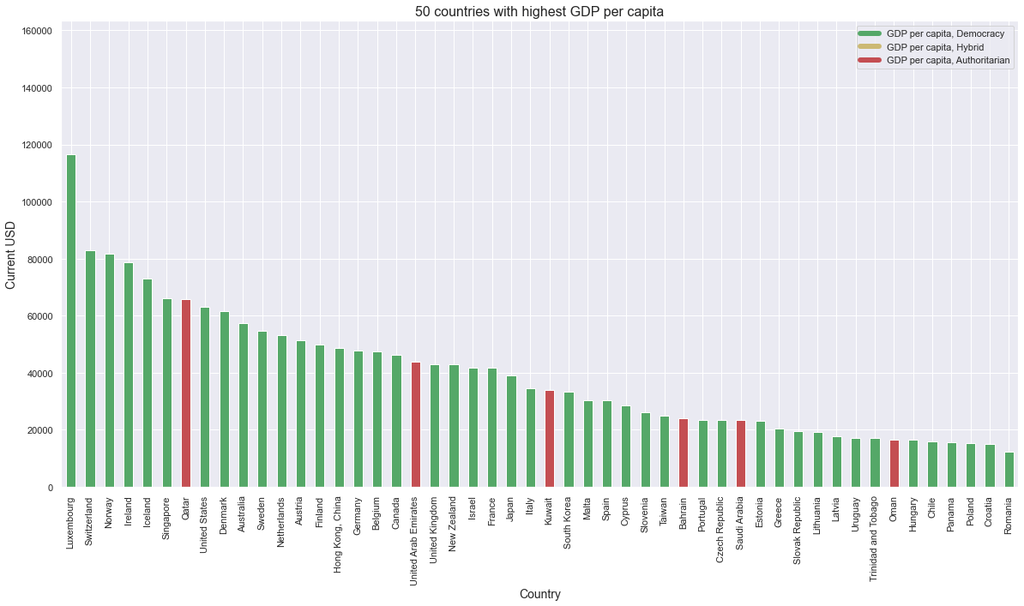

```python
plot_bars_colored_by_regime_type(
    df.sort_values(by=ColGdp.gdp_per_capita, ascending=False).head(num_countries),
    col_name=ColGdp.gdp_per_capita,
    title=f"{num_countries} countries with highest GDP per capita",
    xlabel='Country',
    ylabel='Current USD')
```

## Fuel exports for countries with highest GDP per capita

Get more intution on how wealth relates to fuel exports and regime type

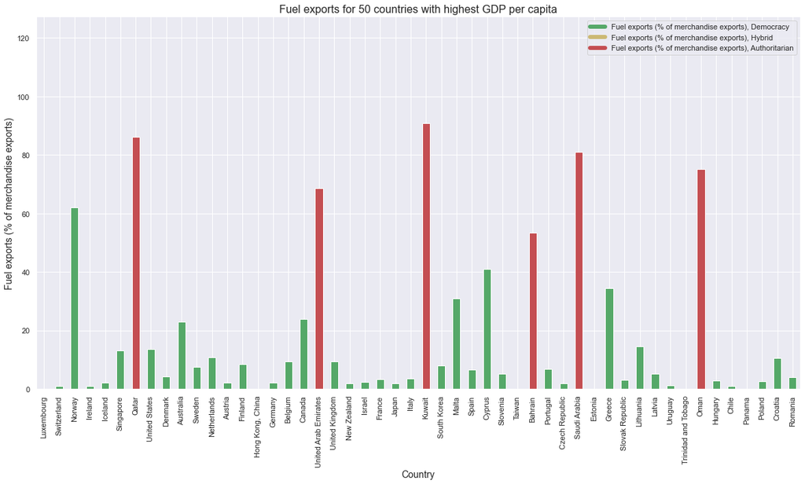

```python
plot_bars_colored_by_regime_type(
    df.sort_values(by=ColGdp.gdp_per_capita, ascending=False).head(num_countries),
    col_name=ColFuel.fuel_exports,
    title=f"Fuel exports for {num_countries} countries with highest GDP per capita",
    xlabel='Country',
    ylabel=ColFuel.fuel_exports)
```

## Average GDP per capita by regime type

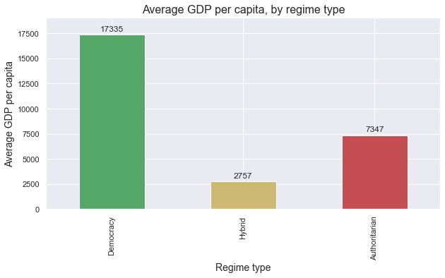

```python
plot_bar_annotated(pop_gdp_by_regime_type[average_gdp_per_capita],
                   title="Average GDP per capita, by regime type",
                   color=ColorRegimeType.values,
                   annotated_values_format=".0f")
```

## Democracy index and GDP per capita

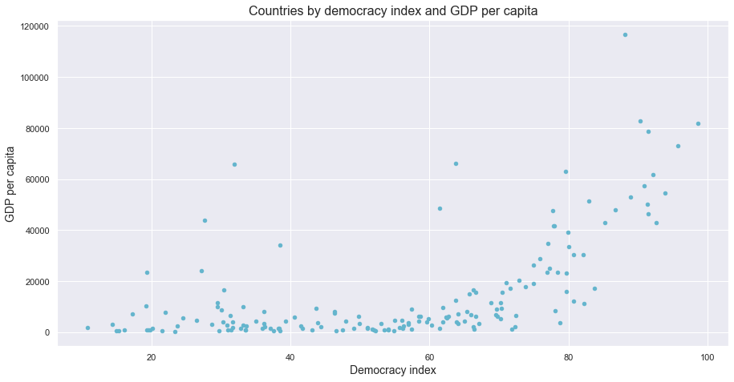

```python
plot_democracy_and_gdp()
```

## Democracy index and GDP per capita, extended

- Circles reflecting population size
- Labels for selected countries
- Different color for "oil-rich" countries

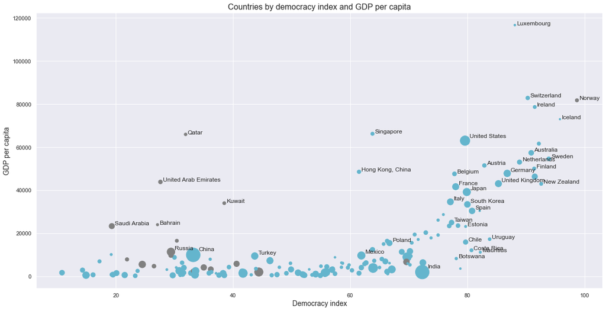

```python
plot_democracy_and_gdp_with_labels()
```

## Summary of findings

```python
df_correlations
```

|  | Pearson correlation coefficient | Interpretation of correlation strength |
| --- | --- | --- |
| Population and democracy index | -0.01 | None |
| GDP per capita and fuel exports percentage for democratic countries | -0.00 | None |
| GDP per capita and fuel exports percentage for authoritarian countries | 0.52 | Rather Strong |
| GDP per capita and democracy index | 0.58 | Rather Strong |
| GDP per capita and democracy index without "oil-rich" countries | 0.66 | Strong |

# Thank you

## Backup: Spurious correlations

- In a spurious correlation (or [spurious relationship](https://en.wikipedia.org/wiki/Spurious_relationship)) events/variables are associated but *not* causally related
- Possible reasons:
  - Common factor ([lurking variable](https://en.wikipedia.org/wiki/Lurking_variable))
  - Coincidence
- An example found [here](https://www.tylervigen.com/spurious-correlations): divorce rate in the Maine and per capita consumption of margarine.

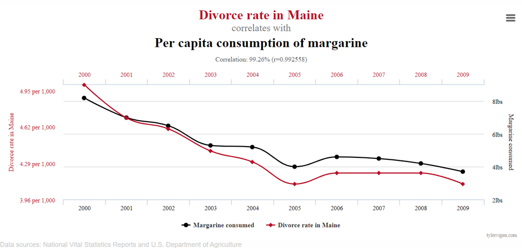

```python
from IPython.display import Image
Image("spurious_correlations_divoce_vs_margarine.PNG")
```